# DHW estimation for Uva Island reef

Ana Palacio

April 12, 2019

```r
# Libraries
  library(lubridate)
  library(tidyverse)
  library(gridExtra)
  library(zoo)
  library(reshape2)
  library(knitr)

# Default ggplot settings
  ggthe_bw<-theme(plot.background=element_blank(),
          panel.grid.major.y = element_blank(),
          panel.grid.major.x = element_blank(),
          panel.grid.minor.x = element_blank(),
          panel.grid.minor.y = element_blank(),
          legend.box.background = element_rect(),
          panel.background =element_rect(fill = NA, color = "black")
          )+
    theme_bw()
```

# 1. Temperature data sources

Obtain temperature data from the different sources

```r
#OI_SST (provided by Ruben van Hooidonk)
    Uva.OI<-read.csv("B.Temperature_data/Uva_Daily_OISST_1982-2016.csv",header = T)
    Uva.OI$Date<-as.Date(Uva.OI$Date, format="%Y-%m-%d")

#InSitu (provided by Tyler Smith)
    Uva.InSitu<-read.csv("B.Temperature_data/Uva_Daily_InSitu_1997-2018.csv", header = T)
    Uva.InSitu$Date<-as.Date(Uva.InSitu$Date, format="%Y-%m-%d")

# CRW-5km SST (provided by Ruben van Hooidonk)
    Uva.CRW<-read.csv("B.Temperature_data/Uva_Daily_CRW_5km_1985-2016.csv",header = T)
    Uva.CRW$Date<-as.Date(Uva.CRW$Date, format="%Y-%m-%d")
```

Compile all temperature data in wide format

```r
Temperature.Wide<-merge(Uva.OI, Uva.InSitu, on=Date, all=TRUE)
Temperature.Wide<-merge(Temperature.Wide, Uva.CRW, on=Date, all=TRUE)
```

Compile all temperature data in tall format

```r
#OISST
    Uva.OI.L<-Uva.OI
    Uva.OI.L$Source<-"OI_SST"
    colnames(Uva.OI.L) <- c("Date","Temperature","Source")

#InSitu
    Uva.InSitu.L<-Uva.InSitu
    Uva.InSitu.L$source<-"In_situ"
    colnames(Uva.InSitu.L) <- c("Date","Temperature", "Source")

# CRW-5km SST
      Uva.CRW.L<-Uva.CRW
      Uva.CRW.L$Source<-"CRW_SST"
      colnames(Uva.CRW.L) <- c("Date", "Temperature", "Source")

Temperature.Tall<-rbind(Uva.OI.L, Uva.InSitu.L, Uva.CRW.L)
```

# 2. Climatology and MMM

## 2.1 OI MMM

Calculate the mean SST per month-year, the monthly mean and then obtain the maximum monthly mean (MMM) using data OISST from 1985-2012.

```r
# Extract months and years from date
  Uva.OI$Month<-month(Uva.OI$Date)
  Uva.OI$Year<-year(Uva.OI$Date)

# Select data from 1985-2012
  Uva.OI.1985_2012<-filter(Uva.OI, Year>1984)
  Uva.OI.1985_2012<-filter(Uva.OI.1985_2012, Year<2013)

# Calculate month-year mean SST
  Uva.OI.MM_1985_2012<-Uva.OI.1985_2012 %>%
    group_by(Month, Year) %>%
    summarize(MM = mean(OISST, na.rm = TRUE))

# Calculate monthly mean SST
  Uva.OI.MonthlyClimatology_1985_2012<-Uva.OI.MM_1985_2012 %>%
    group_by(Month) %>%
    summarize(Clima_M = mean(MM, na.rm = TRUE))
  Uva.OI.MonthlyClimatology_1985_2012
```

| Month | Clima_M |
| --- | --- |
| 1 | 28.73149 |
| 2 | 28.89875 |
| 3 | 29.05537 |
| 4 | 29.16445 |
| 5 | 28.73401 |
| 6 | 28.44962 |
| 7 | 28.45488 |
| 8 | 28.45472 |
| 9 | 28.28292 |
| 10 | 27.83010 |

[output cut: 2 more lines]

```r
# Get maximum monthly mean (MMM)
  MMM_OI<-max(Uva.OI.MonthlyClimatology_1985_2012$Clima_M)
  MMM_OI
```

```
## [1] 29.16445
```

## 2.2 CRW MMM

Import the MMM from CRW 5km suit products

```r
# Calculated MMM
# # Extract months and years from date
#   Uva.CRW$Year<-year(Uva.CRW$Date)
#   Uva.CRW$Month<-month(Uva.CRW$Date)
#
# # Calculate month-year mean SST
#   Uva.CRW.MM<-Uva.CRW %>%
#     group_by(Month, Year) %>%
#     summarize(M_Temeprature = mean(Temperature, na.rm = TRUE))
#
# # Calculate monthly mean SST
#   Uva.CRW.MonthlyClimatology<-Uva.CRW.MM %>%
#     group_by(Month) %>%
#     summarize(Clima_M = mean(M_Temeprature, na.rm = TRUE))
#   Uva.CRW.MonthlyClimatology
#
# # Get maximum monthly mean (MMM)
#   MMM_CRW<-max(Uva.CRW.MonthlyClimatology$Clima_M)
#   MMM_CRW

# Get maximum monthly mean (MMM) from CRW 5km products
  Uva.CRW.MMM<-read.csv("B.Temperature_data/Uva_CRW_MMM_1985-2012.csv", header = T)

  MMM_CRW<-Uva.CRW.MMM[1,1]
  MMM_CRW
```

```
## [1] 28.9
```

## 2.3 In Situ MMM

This code uses in situ available data collected by Tyler Smith et al and calculates an approximated In Situ climatology (~1997-2018, with gaps). The time frame used in this climatology differs from the CWR and OI climatologies. We decided to use all the data available since data were scarcer.

```r
# Extract months and years from date
  Uva.InSitu$Year<-year(Uva.InSitu$Date)
  Uva.InSitu$Month<-month(Uva.InSitu$Date)

# Calculate month-year mean SST
  Uva.InSitu.MM<-Uva.InSitu %>%
    group_by(Month, Year) %>%
    summarize(M_Temeprature = mean(Temperature, na.rm = TRUE))

# Calculate monthly mean SST
  Uva.InSitu.MonthlyClimatology<-Uva.InSitu.MM %>%
    group_by(Month) %>%
    summarize(Clima_M = mean(M_Temeprature, na.rm = TRUE))
  Uva.InSitu.MonthlyClimatology
```

| Month | Clima_M |
| --- | --- |
| 1 | 28.72888 |
| 2 | 28.75388 |
| 3 | 28.79994 |
| 4 | 29.05983 |
| 5 | 28.81287 |
| 6 | 28.56698 |
| 7 | 28.68233 |
| 8 | 28.75810 |
| 9 | 28.51346 |
| 10 | 27.99157 |

[output cut: 2 more lines]

```r
# Get maximum monthly mean (MMM)
  MMM_InSitu<-max(Uva.InSitu.MonthlyClimatology$Clima_M)
  MMM_InSitu
```

```
## [1] 29.05983
```

Notes about MMMs

- Values: CRW MMM (28.9 C) < Insitu MMM (29.05983 C) < OI MMM (29.16445 C)
- Observations: Insitu MMM (n=7,864 days) < CRW MMM (n=10,227) = OI MMM (n=10,227)
- Time frame: Insitu MMM (1997-2018, with gaps) < CRW MMM (1985-2012) = OI MMM (1985-2012)

Calculated CRW MMM is higher (29.09882 C) than MMM extracted directly from the 5km products (28.9 C), (ftp://ftp.star.nesdis.noaa.gov/pub/sod/mecb/crw/data/5km/v3.1/climatology/nc/ct5km_climatology_v3.1.nc).

https://coralreefwatch.noaa.gov/satellite/bleaching5km/index.php says: This 28-year climatology covers the time period 1985-2012 and is based on the daily global 5km ‘CoralTemp’ SST data product. This 5km climatology was re-centered to the time-center of the operational 50km climatology (1985-1990 plus 1993) to maintain consistency with the former Version 2 5km climatology and CRW’s heritage 50km products. Not really sure how the data are “re-centered”, but this seems to lower the MMM.

# 3. DHW

## 3.1 OISST DHW calculation

This code uses a mixed approach (Ruben van Hooidonk + CRW) to estimate DHW, based on OI_SST data:

- SST data source is OI_SST v2, not CRW (CoralTemp). OI data were initially preferred because CRW data start in 1985 and missed the 1982-83 ENSO
- MMM values used are the calculated above, based on OI_SST_v2 SST from the period 1985-2012. This is the same period used for the CRW_5KM_V3_climatology.
- OISST has one temperature value per day, there is no distinction between day/night SST as there is in CRW products
- HotSpots are calculated daily, then divided by 7 to calculate DHW from DHDays

```r
##### Calculate IO DHW
      Uva.OI.L$HotSpot<-(Uva.OI.L$Temperature-(MMM_OI))
      Uva.OI.L$HotSpot<-ifelse(Uva.OI.L$HotSpot>=0,
                              Uva.OI.L$HotSpot, 0)# REMOVE NEGATIVE ANOMALIES
      Uva.OI.L$Stress<-ifelse(Uva.OI.L$HotSpot>=1,
                              Uva.OI.L$HotSpot, 0) # REMOVE HotSpot lower than 1
      Uva.OI.L$W_Stress<-(Uva.OI.L$Stress/7) # DHDays to DHWeeks
      Uva.OI.L$DHW<-rollapplyr(Uva.OI.L$W_Stress,list(-(83:0)),sum,fill=NA)# Add 12 weeks of heat stress data
```

## 3.2 CRW SST DHW calculation

This code uses CRW MMM and CRW SST data to estimate DHW:

- MMM values used were extracted from the CWR 5km climatology that includes 1985-2012 data. Calculated MMM value is slightly different (warmer) than MMM value extracted from CRW_5KM_V3_climatology.

```r
##### Calculate CRW DHW based on CRW MMM
      Uva.CRW.L$HotSpot<-(Uva.CRW.L$Temperature-(MMM_CRW))
      Uva.CRW.L$HotSpot<-ifelse(Uva.CRW.L$HotSpot>=0,
                              Uva.CRW.L$HotSpot, 0)# REMOVE NEGATIVE ANOMALIES
      Uva.CRW.L$Stress<-ifelse(Uva.CRW.L$HotSpot>=1,
                              Uva.CRW.L$HotSpot, 0) # REMOVE HotSpot lower than 1
      Uva.CRW.L$W_Stress<-(Uva.CRW.L$Stress/7) # DHDays to DHWeeks
      Uva.CRW.L$DHW<-rollapplyr(Uva.CRW.L$W_Stress,list(-(83:0)),sum,fill=NA)# Add 12 weeks of heat stress data
```

## 3.3 InSitu DHW calculation

This code uses a mixed approach (Ruben van Hooidonk + CRW) to estimate DHW, based on In situ data:

- Temperature data source are Tyler Smith’s Hobo temps, not CRW SST.
- MMM values used are the calculated above, based HOBOs’ data from the period ~ 1997-2018. This is a different period than the one used for the CRW_5KM_V3_climatology, but it is the range available. The data present gaps
- Daily mean temperatures were calculated using all the data available for a day (day + night)
- HotSpots are calculated daily, then divided by 7 to calculate DHW from DHDays

```r
##### Calculate IO DHW
      Uva.InSitu.L$HotSpot<-(Uva.InSitu.L$Temperature-(MMM_InSitu))
      Uva.InSitu.L$HotSpot<-ifelse(Uva.InSitu.L$HotSpot>=0,
                              Uva.InSitu.L$HotSpot, 0)# REMOVE NEGATIVE ANOMALIES
      Uva.InSitu.L$Stress<-ifelse(Uva.InSitu.L$HotSpot>=1,
                              Uva.InSitu.L$HotSpot, 0) # Select HotSpots >=1
      Uva.InSitu.L$W_DHW<-(Uva.InSitu.L$Stress/7)
      Uva.InSitu.L$DHW<-rollapplyr(Uva.InSitu.L$W_DHW,list(-(83:0)),sum,fill=NA)
```

# 4. DHW plots

## 4.1 Explore available data based on all data sources

```r
# Wide DHW
    DHW.InSitu.W<-Uva.InSitu.L[, c("Date","DHW")]
    colnames(DHW.InSitu.W) <- c("Date","InSitu_DHW")

    DHW.CRW.W<-Uva.CRW.L[, c("Date","DHW")]
    colnames(DHW.CRW.W) <- c("Date","CRW_DHW")

    DHW.OI.W<-Uva.OI.L[, c("Date", "DHW")]
    colnames(DHW.OI.W) <- c("Date","OI_DHW")

    DHW.Wide<-merge(DHW.InSitu.W, DHW.CRW.W, on=Date, all=TRUE)
    DHW.Wide<-merge(DHW.Wide, DHW.OI.W, on=Date, all=TRUE)

# Long DHW data
    Uva.InSitu.DHW<-Uva.InSitu.L[, c("Source", "Date", "Temperature", "HotSpot", "DHW")]
    Uva.CRW.DHW<-Uva.CRW.L[, c("Source", "Date", "Temperature",  "HotSpot", "DHW")]
    Uva.OI.DHW<-Uva.OI.L[, c("Source", "Date", "Temperature",  "HotSpot", "DHW")]

    Long.data.DHW<-rbind(Uva.InSitu.DHW,Uva.CRW.DHW,Uva.OI.DHW)
    Long.data.DHW$Source<-factor(Long.data.DHW$Source,
                            levels = c("OI_SST","CRW_SST","In_situ"))
    Long.data.DHW$Year<-lubridate::year(Long.data.DHW$Date)
    Long.data.DHW$Month<-lubridate::month(Long.data.DHW$Date)

# Highest DWH per year
    MaxDHW<-as.data.frame(Long.data.DHW %>%
          group_by(Source, Year) %>%
          summarize(max = max(DHW, na.rm = TRUE)))
    MaxDHW<-dcast(MaxDHW, Year ~ Source, value.var = "max")
    MaxDHW
```

| Year | OI_SST | CRW_SST | In_situ |
| --- | --- | --- | --- |
| 1981 | 0.0000000 | NA | NA |
| 1982 | 0.7925338 | NA | NA |
| 1983 | 7.5693232 | NA | NA |
| 1984 | 0.5309489 | NA | NA |
| 1985 | 0.0000000 | 0.3128573 | NA |
| 1986 | 0.0000000 | 0.0000000 | NA |
| 1987 | 0.0000000 | 0.1457144 | NA |
| 1988 | 0.3787280 | 1.1714292 | NA |
| 1989 | 0.0000000 | 0.0000000 | NA |
| 1990 | 0.0000000 | 0.3042859 | NA |

[output cut: 28 more lines]

```r
# Highest HotSpot per year
  MaxHS<-as.data.frame(Long.data.DHW %>%
        group_by(Source, Year) %>%
        summarize(max = max(HotSpot, na.rm = TRUE)))
  MaxHS<-dcast(MaxHS, Year ~ Source, value.var = "max")
  MaxHS
```

| Year | OI_SST | CRW_SST | In_situ |
| --- | --- | --- | --- |
| 1981 | 0.0000000 | NA | NA |
| 1982 | 1.4755477 | NA | NA |
| 1983 | 2.8355483 | NA | NA |
| 1984 | 1.2955473 | NA | NA |
| 1985 | 0.4255484 | 1.1600006 | NA |
| 1986 | 0.4055480 | 0.6400006 | NA |
| 1987 | 0.6255473 | 1.0200006 | NA |
| 1988 | 1.4055480 | 1.5000006 | NA |
| 1989 | 0.7655467 | 0.8300006 | NA |
| 1990 | 0.8655470 | 1.1300006 | NA |

[output cut: 28 more lines]

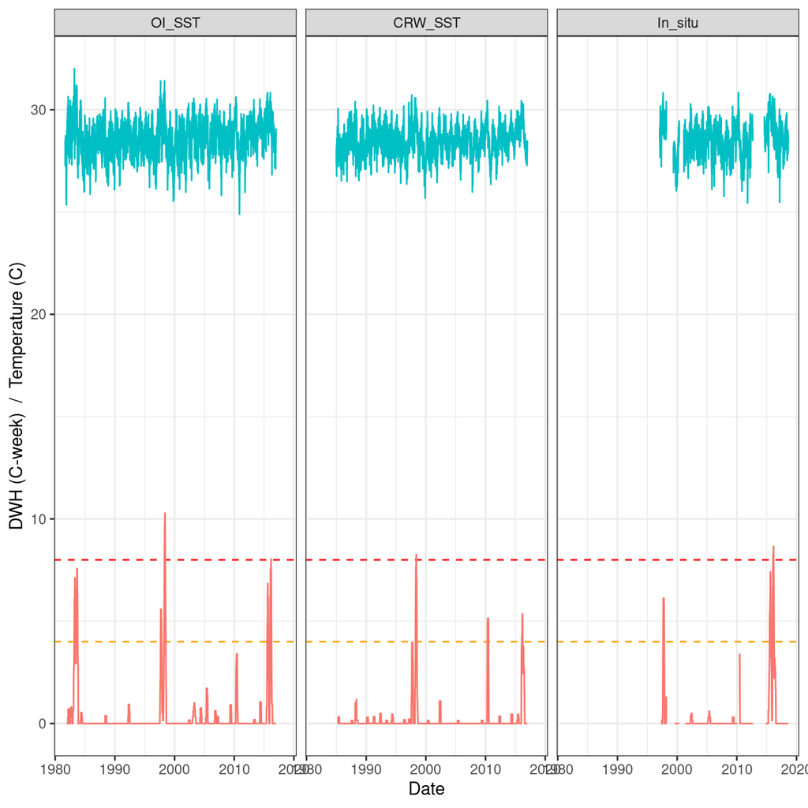

```r
# Plot data
AllSources<-ggplot(Long.data.DHW, aes(x=Date)) +
    ggthe_bw+ theme(legend.position = "none")+
    facet_wrap(~Source)+
    geom_hline(yintercept=8, linetype="dashed", color="red")+
    geom_hline(yintercept=4, linetype="dashed", color="orange")+
    geom_line(aes(y = Temperature, colour = "Temperature")) +
    geom_line(aes(y = DHW, colour = "DWH")) +
    ylab("DWH (C-week)  /  Temperature (C)")
AllSources
```

## 4.2 Comparison of the 3 ENSO events based on OISST data

```r
# 1. Extract only 1982-83, 1997-98 and 2015-16 Data

  # 1981-82
    Days<-as.data.frame(seq(1,730,by=1))
    names(Days) <- c("Days")

    N_1982<-as.data.frame(seq(as.Date("1982-01-01"),
                              as.Date("1983-12-31"), by="days"))
        names(N_1982) <- c("Date")
        N_1982<-cbind(Days, N_1982)
        N_1982$Event<-"1982-83"
        tail(N_1982,n=2)
```

|  | Days | Date | Event |
| --- | --- | --- | --- |
| 729 | 729 | 1983-12-30 | 1982-83 |
| 730 | 730 | 1983-12-31 | 1982-83 |

```r
  # 1997-98
    N_1997<-as.data.frame(seq(as.Date("1997-01-01"),
                              as.Date("1998-12-31"), by="days"))
        names(N_1997) <- c("Date")
        N_1997<-cbind(Days,N_1997)
        N_1997$Event<-"1997-98"
        tail(N_1997,n=2)
```

|  | Days | Date | Event |
| --- | --- | --- | --- |
| 729 | 729 | 1998-12-30 | 1997-98 |
| 730 | 730 | 1998-12-31 | 1997-98 |

```r
  # 2015-16
    Days<-as.data.frame(seq(1,731,by=1)) # 2015-2016 Needs an extra day
    names(Days) <- c("Days")

    N_2015<-as.data.frame(seq(as.Date("2015-01-01"),
                              as.Date("2016-12-31"), by="days"))
        names(N_2015) <- c("Date")
        N_2015<-cbind(Days, N_2015)
        N_2015$Event<-"2015-16"
        tail(N_2015,n=2)
```

|  | Days | Date | Event |
| --- | --- | --- | --- |
| 730 | 730 | 2016-12-30 | 2015-16 |
| 731 | 731 | 2016-12-31 | 2015-16 |

```r
  # ENSO years
    ENSO_Dates<-rbind(N_1982, N_1997, N_2015)

Nino.OI_data<-merge(x = ENSO_Dates, y = Uva.OI.L, by = "Date", all.x = TRUE)
Nino.OI_data$Dates<-format(Nino.OI_data$Date, format= "%m-%d")
#head(Nino.OI_data,n=2)
#tail(Nino.OI_data,n=2)
```

### Figure 1a

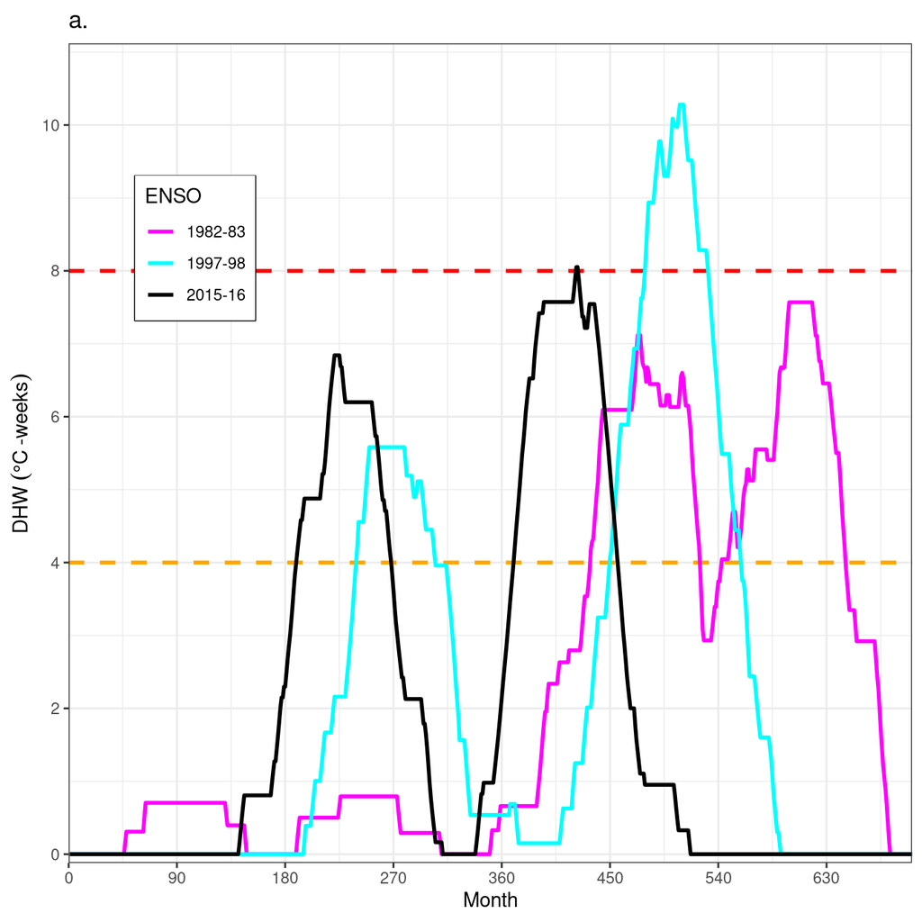

```r
Figure1a<-ggplot(Nino.OI_data, aes(x=Days)) + ggtitle("a.")+ ggthe_bw+
  theme(legend.box.background = element_rect(),
        legend.position = c(0.15, 0.75)) +
  geom_hline(yintercept=8, linetype="dashed", color="red", size=1)+
  geom_hline(yintercept=4, linetype="dashed", color="orange", size=1)

Figure1a <-Figure1a +
  geom_line(aes(y = DHW, colour = factor(Event)), size=1.0) +
  scale_x_continuous(limits = c(0,701), expand = c(0, 0),
                     name=("Month"),
                     breaks = seq(0,701, by= 90))+
  scale_y_continuous(limits = c(0,11),
                     name=(expression("DHW"~(degree*C ~"-weeks"))), expand = c(0.01, 0.01),
                     breaks = seq(0,10, by=2)) +
  scale_colour_manual(values = c("magenta","cyan", "black"), name="ENSO")
Figure1a
```

```r
#ggsave(file="C.Outputs/Figure_1a.svg", plot=Figure1a, width=6.5, height=3.5)
```

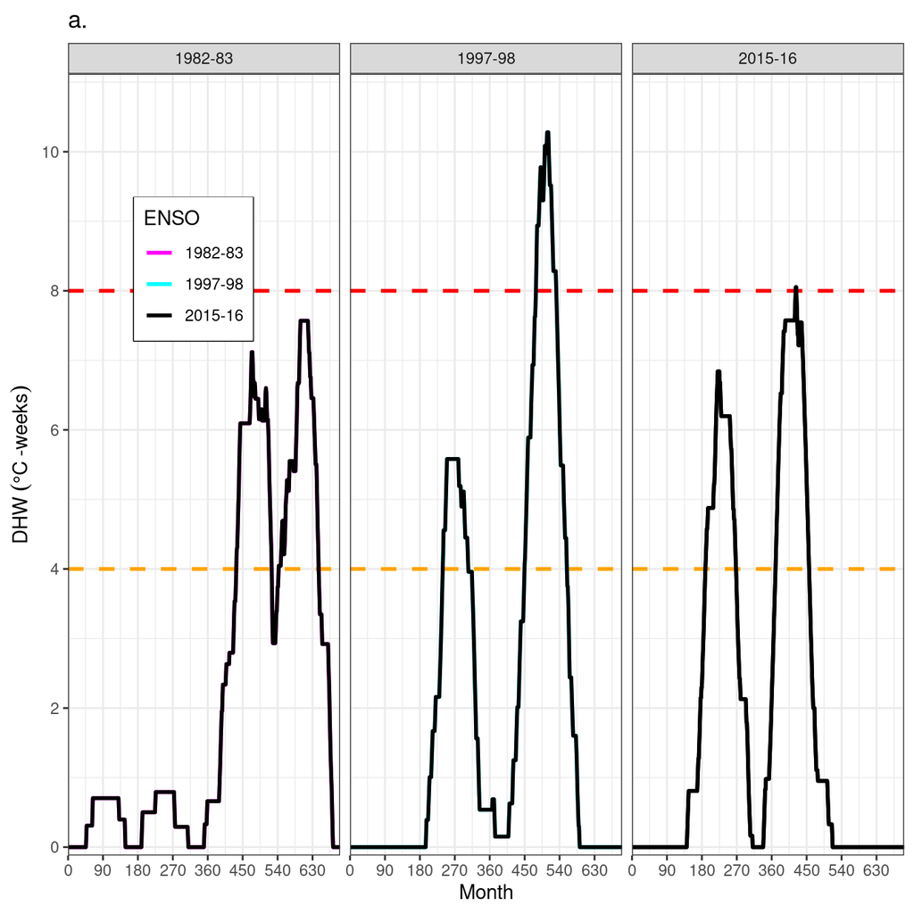

```r
Figure1a2 <-Figure1a +
  geom_line(aes(y = DHW), size=1.0) +
  scale_x_continuous(limits = c(0,701), expand = c(0, 0),
                     name=("Month"),
                     breaks = seq(0,701, by= 90))+
  scale_y_continuous(limits = c(0,11),
                     name=(expression("DHW"~(degree*C ~"-weeks"))), expand = c(0.01, 0.01),
                     breaks = seq(0,10, by=2)) +
  facet_grid(~Event)
Figure1a2
```

```r
#ggsave(file="C.Outputs/Figure_1a2.svg", plot=Figure1a2, width=7, height=4)
```

**Figure 1a**: Accumulated heat stress and thermal regime at Uva Island, Gulf of Chiriquí. **a.** Degree heating weeks (DHW) during the 1982-83, 1997-98 and 2015-16 ENSOs estimated using daily OISST data. The yellow dashed line marks the 4 DHW threshold for significant likelihood of bleaching, and the red dashed line marks 8 DHW threshold for significant likelihood of mortality.

## 4.3 Temperature and DHW during 2015-16 ENSO events based on OI and InSitu data

### Figure 2a

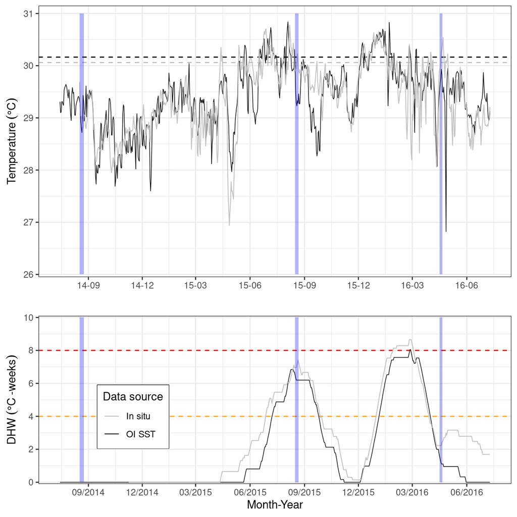

```r
 # Figure 1b

TemperaturePlot<-ggplot(Temperature.Wide, aes(x=Date)) + ggthe_bw+
    theme(legend.position = "none") +
    scale_colour_manual(values = c("gray", "black"), name="Source")
    #scale_colour_manual(values = c("black", "blue4","grey"), name="Source")

TemperaturePlot<-TemperaturePlot +
  geom_hline(yintercept=MMM_OI+1, linetype="dashed", color="black")+
  geom_hline(yintercept=MMM_InSitu+1, linetype="dashed", color="grey")+
  #geom_hline(yintercept=MMM_CRW+1, linetype="dashed", color="blue4")+
  geom_line(aes(y = (OISST), colour = "OI_SST"), linetype=1, size=0.3, alpha=0.9) +
  geom_line(aes(y = (Temperature), colour = "In situ"), size=0.4, alpha=0.9) +
  #geom_line(aes(y = (CRWSST), colour = "CRW_SST"), linetype=1, size=0.3, alpha=0.9) +

  scale_x_date(date_breaks = "3 months", date_labels = "%y-%m",
               limits = c(as.Date("2014-07-15"), as.Date("2016-07-10")),
               name = "") +
  scale_y_continuous(limits = c(26,31.1), expand = c(0.01, 0),
                   name=(expression("Temperature"~(degree*C))),
                   breaks = seq(26,31, by=1))+
  annotate("rect", xmin= as.Date("2014-08-17"), xmax = as.Date("2014-08-24"),
                 ymin = 26, ymax = 31, fill="blue", alpha = .3) +
  annotate("rect", xmin= as.Date("2015-08-16"), xmax = as.Date("2015-08-22"),
                 ymin = 26, ymax = 31, fill="blue", alpha = .3) +
  annotate("rect", xmin= as.Date("2016-04-16"), xmax = as.Date("2016-04-21"),
                 ymin = 26, ymax = 31, fill="blue", alpha = .3)

DHWPlot<-ggplot(DHW.Wide, aes(x=Date)) + ggthe_bw+
   theme(legend.box.background = element_rect(),
        legend.position = c(0.2, 0.4)) +
  scale_colour_manual(values = c("gray", "black"), name="Data source")
  #scale_colour_manual(values = c("blue4", "gray","black"), name="Source")
DHWPlot<-DHWPlot +
    geom_hline(yintercept=8, linetype="dashed", color="red", size=0.5)+
    geom_hline(yintercept=4, linetype="dashed", color="orange", size=0.5)+
    geom_line(aes(y = (OI_DHW), colour = "OI SST"), linetype=1, size=0.3, alpha=0.9) +
    geom_line(aes(y = (InSitu_DHW), colour = "In situ"), size=0.4, alpha=0.9) +
    #geom_line(aes(y = (CRW_DHW), colour = "CRW"), size=0.4, alpha=0.9) +
    scale_x_date(date_breaks = "3 months", date_labels = "%m/%Y",
               limits = c(as.Date("2014-07-15"), as.Date("2016-07-10")),
               name = "Month-Year") +
    scale_y_continuous(limits = c(0,10), expand = c(0.01, 0),
                   name=(expression("DHW"~(degree*C~"-weeks"))),
                   breaks = seq(0,10, by=2))+
    annotate("rect", xmin= as.Date("2014-08-17"), xmax = as.Date("2014-08-24"),
                 ymin = 0, ymax = 10, fill="blue", alpha = .3) +
    annotate("rect", xmin= as.Date("2015-08-16"), xmax = as.Date("2015-08-22"),
                 ymin = 0, ymax = 10, fill="blue", alpha = .3) +
    annotate("rect", xmin= as.Date("2016-04-16"), xmax = as.Date("2016-04-21"),
                 ymin = 0, ymax = 10, fill="blue", alpha = .3)

Figure2a_Final<-grid.arrange(TemperaturePlot, DHWPlot, nrow=2, heights=c(6/10, 4/10))
```

```r
#ggsave(file="C.Outputs/Figure_1b.svg", plot=Figure2a_Final, width=6.5, height=4.5)
```

# 5. Potential bias based on data source (Supplementary Information)

## 5.1 SST with data from 2014-2016

```r
  Temperature.Wide$Year<-year(Temperature.Wide$Date)
  Temperature.Wide_2014_2016<-filter(Temperature.Wide, Year>2013)
  Temperature.Wide_2014_2016<-filter(Temperature.Wide_2014_2016, Year<2017)
  summary(Temperature.Wide_2014_2016$OISST)
```

```
##    Min. 1st Qu.  Median    Mean 3rd Qu.    Max.
##   26.82   28.88   29.31   29.25   29.72   30.84
```

```r
  summary(Temperature.Wide_2014_2016$CRWSST )
```

```
##    Min. 1st Qu.  Median    Mean 3rd Qu.    Max.
##   27.28   28.50   28.94   28.91   29.32   30.44
```

```r
  summary(Temperature.Wide_2014_2016$Temperature)
```

```
##    Min. 1st Qu.  Median    Mean 3rd Qu.    Max.    NA's
##   26.70   28.63   29.17   29.15   29.81   30.78     228
```

### Figure S1

```
##
## Call:
## lm(formula = OISST ~ Temperature, data = Temperature.Wide_2014_2016)
##
## Residuals:
##      Min       1Q   Median       3Q      Max
## -3.10534 -0.24675  0.03016  0.28238  1.48478
##
## Coefficients:
##             Estimate Std. Error t value Pr(>|t|)
## (Intercept)  6.90978    0.53350   12.95   <2e-16 ***
## Temperature  0.76482    0.01829   41.80   <2e-16 ***
## ---
## Signif. codes:  0 '***' 0.001 '**' 0.01 '*' 0.05 '.' 0.1 ' ' 1
##
## Residual standard error: 0.4323 on 866 degrees of freedom
##   (228 observations deleted due to missingness)
## Multiple R-squared:  0.6687, Adjusted R-squared:  0.6683
## F-statistic:  1748 on 1 and 866 DF,  p-value: < 2.2e-16
```

```
##
## Call:
## lm(formula = CRWSST ~ Temperature, data = Temperature.Wide_2014_2016)
##
## Residuals:
##      Min       1Q   Median       3Q      Max
## -1.06653 -0.31235 -0.06539  0.27989  1.58472
##
## Coefficients:
##             Estimate Std. Error t value Pr(>|t|)
## (Intercept) 10.42236    0.53621   19.44   <2e-16 ***
## Temperature  0.63324    0.01839   34.44   <2e-16 ***
## ---
## Signif. codes:  0 '***' 0.001 '**' 0.01 '*' 0.05 '.' 0.1 ' ' 1
##
## Residual standard error: 0.4345 on 866 degrees of freedom
##   (228 observations deleted due to missingness)
## Multiple R-squared:  0.578,  Adjusted R-squared:  0.5775
## F-statistic:  1186 on 1 and 866 DF,  p-value: < 2.2e-16
```

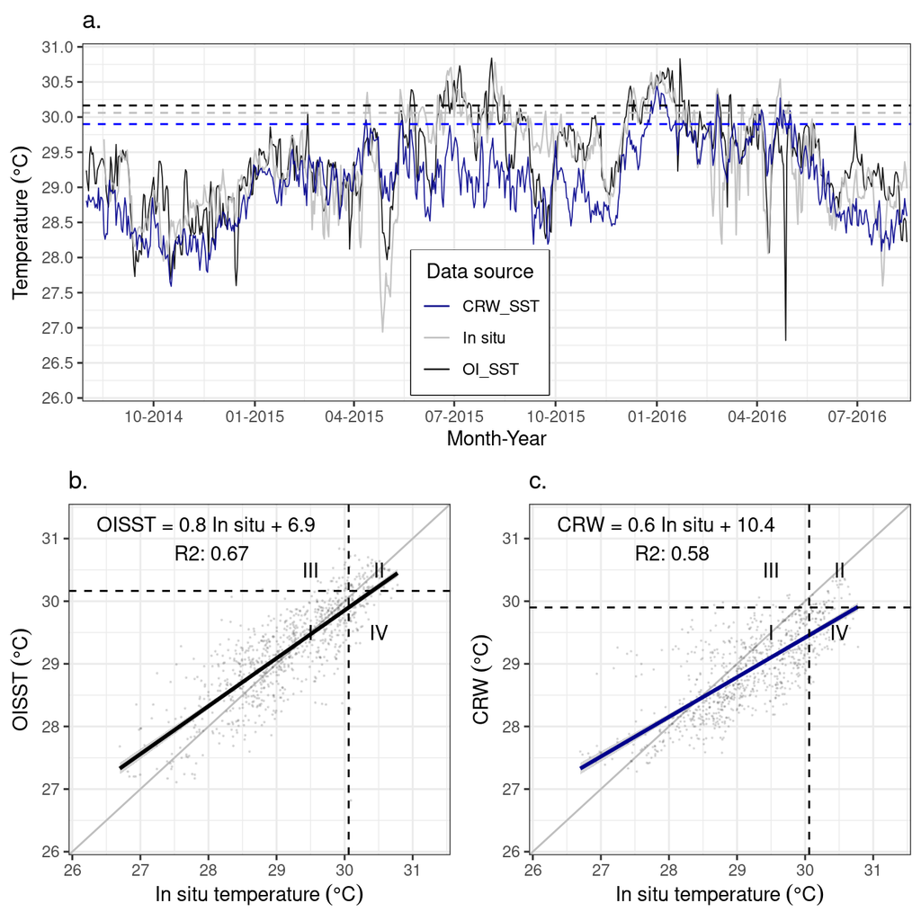

**Supplementary Figure S1:** Temperature comparison among different data sources. **a.** Temperature for the August 2014 - August 2016 period. **b.** Correlation between OISST (v2) data and *in situ* (3m) data. **c.** Correlation between CRW (CoralTemp v3.1) and *in situ* data. Panels I contain SST values under the bleaching threshold for both data sets being compared (there is not accumulation of DHW). Panels II contain SST values above the bleaching threshold for both data sets being compared (both data sets accumulate of DHW). Panels III contain the cases in which satellite values were above the bleaching threshold, both not the *in situ* values (potential DHW overestimation). Panels IV contain the cases in which *in situ* values were above the bleaching threshold, both not the satellite values (potential DHW underestimation).

## 5.2 SST with all data from any year with the 3 sources

```r
  Temperature.Wide.All<-Temperature.Wide[complete.cases(Temperature.Wide), ]
```

```
##
## Call:
## lm(formula = OISST ~ Temperature, data = Temperature.Wide)
##
## Residuals:
##      Min       1Q   Median       3Q      Max
## -3.07279 -0.31868  0.04338  0.34622  1.99901
##
## Coefficients:
##             Estimate Std. Error t value Pr(>|t|)
## (Intercept) 5.826754   0.256110   22.75   <2e-16 ***
## Temperature 0.799726   0.008955   89.30   <2e-16 ***
## ---
## Signif. codes:  0 '***' 0.001 '**' 0.01 '*' 0.05 '.' 0.1 ' ' 1
##
## Residual standard error: 0.5533 on 5813 degrees of freedom
##   (7678 observations deleted due to missingness)
## Multiple R-squared:  0.5784, Adjusted R-squared:  0.5783
## F-statistic:  7975 on 1 and 5813 DF,  p-value: < 2.2e-16
```

```
##
## Call:
## lm(formula = CRWSST ~ Temperature, data = Temperature.Wide)
##
## Residuals:
##      Min       1Q   Median       3Q      Max
## -1.57787 -0.26038 -0.00314  0.24734  1.97499
##
## Coefficients:
##             Estimate Std. Error t value Pr(>|t|)
## (Intercept) 7.916719   0.188561   41.98   <2e-16 ***
## Temperature 0.719924   0.006593  109.19   <2e-16 ***
## ---
## Signif. codes:  0 '***' 0.001 '**' 0.01 '*' 0.05 '.' 0.1 ' ' 1
##
## Residual standard error: 0.4073 on 5813 degrees of freedom
##   (7678 observations deleted due to missingness)
## Multiple R-squared:  0.6722, Adjusted R-squared:  0.6722
## F-statistic: 1.192e+04 on 1 and 5813 DF,  p-value: < 2.2e-16
```

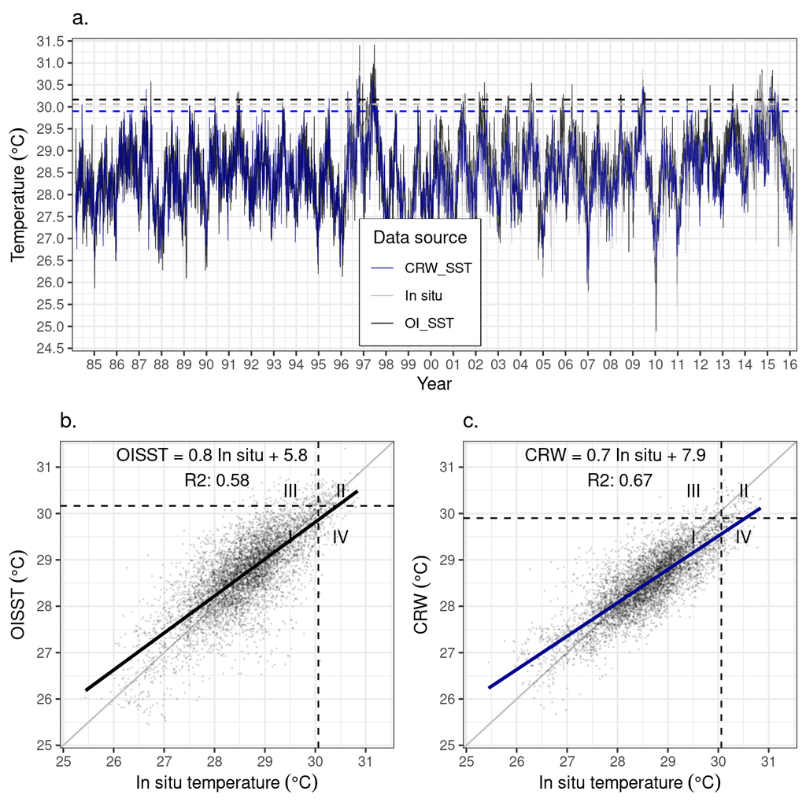

## 5.3 DHW with data from 2014-2016

```r
# Organize the data source
Wide.data.DHW<-dplyr::filter(Long.data.DHW, Year>2013)
Wide.data.DHW<-dplyr::filter(Wide.data.DHW, Year<2017)
Wide.data.DHW<-Wide.data.DHW %>%
              dplyr::select(Source, Date, DHW)

Wide.data.DHW2<-reshape(Wide.data.DHW,
                        idvar = "Date", timevar = "Source", direction = "wide")

#Wide.data.DHW2<-Wide.data.DHW2[complete.cases (Wide.data.DHW2),]
#head(Wide.data.DHW2)
#tail(Wide.data.DHW2)
```

### Figure S2

```
##
## Call:
## lm(formula = DHW.OI_SST ~ DHW.In_situ, data = Wide.data.DHW2)
##
## Residuals:
##     Min      1Q  Median      3Q     Max
## -2.1786 -0.2485  0.3756  0.3756  1.6963
##
## Coefficients:
##              Estimate Std. Error t value Pr(>|t|)
## (Intercept) -0.375601   0.034351  -10.93   <2e-16 ***
## DHW.In_situ  0.915716   0.009934   92.18   <2e-16 ***
## ---
## Signif. codes:  0 '***' 0.001 '**' 0.01 '*' 0.05 '.' 0.1 ' ' 1
##
## Residual standard error: 0.7367 on 783 degrees of freedom
##   (311 observations deleted due to missingness)
## Multiple R-squared:  0.9156, Adjusted R-squared:  0.9155
## F-statistic:  8496 on 1 and 783 DF,  p-value: < 2.2e-16
```

```
##
## Call:
## lm(formula = DHW.CRW_SST ~ DHW.In_situ, data = Wide.data.DHW2)
##
## Residuals:
##      Min       1Q   Median       3Q      Max
## -2.83582 -0.23727 -0.08136  0.38007  2.98418
##
## Coefficients:
##             Estimate Std. Error t value Pr(>|t|)
## (Intercept)  0.08136    0.05460    1.49    0.137
## DHW.In_situ  0.37167    0.01579   23.54   <2e-16 ***
## ---
## Signif. codes:  0 '***' 0.001 '**' 0.01 '*' 0.05 '.' 0.1 ' ' 1
##
## Residual standard error: 1.171 on 783 degrees of freedom
##   (311 observations deleted due to missingness)
## Multiple R-squared:  0.4144, Adjusted R-squared:  0.4137
## F-statistic: 554.1 on 1 and 783 DF,  p-value: < 2.2e-16
```

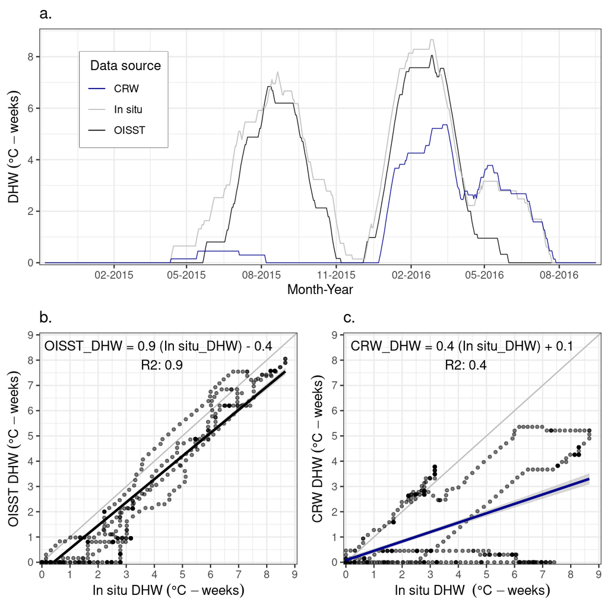

**Supplementary Figure S2:** Degree heating weeks (DHW) index comparison among different data sources. **a.** DHW calculated for November 2014 - August 2016. **b.** Correlation between OISST derived in situ derived DHW indices. **c.** Correlation between CRW (CoralTemp v3.1) derived and in situ derived DHW indices.

## 5.4 DHW with all DHW data available for all 3 sources

```r
# Organize the data source

  Wide.data.DHW<-Long.data.DHW %>%
                dplyr::select(Source, Date, DHW)

  Wide.data.DHW3<-reshape(Wide.data.DHW,
                          idvar = "Date", timevar = "Source", direction = "wide")

  # Wide.data.DHW2<-Wide.data.DHW2[complete.cases (Wide.data.DHW2),]
  #head(Wide.data.DHW2)
  #tail(Wide.data.DHW2)
```

```r
# a. Estimated DHW

    DHWSource2<-ggplot(Wide.data.DHW3, aes(x=Date)) +
       ggthe_bw + ggtitle("a.") +
       scale_x_date(date_breaks = "24 months", date_labels = "%Y",
                    limits = c(as.Date("1997-01-01"), as.Date("2016-12-31")),
                    expand = c(0.01, 0),
                    name = "Month-Year") +
      scale_y_continuous(limits = c(0,11), expand = c(0.01, 0),
                         name=(expression("DHW"~(degree*C~-"weeks"))),
                         breaks = seq(0,10, by=2))+
      theme(legend.box.background = element_rect(),
            legend.position = c(0.25, 0.7))+

      geom_line(aes(y = (DHW.OI_SST), colour = "OISST"), linetype=1, size=0.3, alpha=0.9) +
      geom_line(aes(y = (DHW.In_situ), colour = "In situ"), size=0.4, alpha=0.9) +
      geom_line(aes(y = (DHW.CRW_SST), colour = "CRW"), linetype=1, size=0.3, alpha=0.9) +
      scale_colour_manual(values = c("blue4","grey","black"), name=" Data source")
    #DHWSource2
    #ggsave(file="Outputs/Sup_DHW_Source2.svg", plot=DHWSource2, width=8, height=3.5)


# b. OI versus In situ

    LM_OI_DWW2<-lm(DHW.OI_SST~DHW.In_situ, data = Wide.data.DHW3)
    summary(LM_OI_DWW2)
```

```
##
## Call:
## lm(formula = DHW.OI_SST ~ DHW.In_situ, data = Wide.data.DHW3)
##
## Residuals:
##      Min       1Q   Median       3Q      Max
## -2.44465 -0.06661 -0.06661 -0.06661  2.06520
##
## Coefficients:
##             Estimate Std. Error t value Pr(>|t|)
## (Intercept) 0.066607   0.005964   11.17   <2e-16 ***
## DHW.In_situ 0.852559   0.003937  216.57   <2e-16 ***
## ---
## Signif. codes:  0 '***' 0.001 '**' 0.01 '*' 0.05 '.' 0.1 ' ' 1
##
## Residual standard error: 0.4174 on 5398 degrees of freedom
##   (8093 observations deleted due to missingness)
## Multiple R-squared:  0.8968, Adjusted R-squared:  0.8968
## F-statistic: 4.69e+04 on 1 and 5398 DF,  p-value: < 2.2e-16
```

```r
    GCITYvsOI_DHW2<-ggplot(Wide.data.DHW3, aes(x=DHW.In_situ, y=DHW.OI_SST)) +
      ggthe_bw + ggtitle("b.")+

      geom_abline(slope = 1, intercept = 0, colour="grey")+
      geom_point(alpha=0.5, size=1)+
      geom_smooth(method = lm, colour="black")+

      scale_y_continuous(limits = c(0,9), expand = c(0.01, 0),
                         name=(expression("OISST DHW"~(degree*C~-weeks))),
                         breaks = seq(0,9, by=1))+
      scale_x_continuous(limits = c(0,9), expand = c(0.01, 0),
                         name=(expression("In situ DHW"~(degree*C~-weeks))),
                         breaks = seq(0,9, by=1))+

      annotate("text", x = 4.2, y = 8.2, label = "OISST_DHW = 0.8 (In situ_DHW) + 0.1 \n R2: 0.9")
    #GCITYvsOI_DHW2
    # ggsave(file="Outputs/DHW_IS_OI_2.svg", plot=GCITYvsOI_DHW2, width=4, height=3.5)


# c. CRW versus In situ

    LM_CRW_DHW2<-lm(DHW.CRW_SST~DHW.In_situ, data = Wide.data.DHW3)
    summary(LM_CRW_DHW2)
```

```
##
## Call:
## lm(formula = DHW.CRW_SST ~ DHW.In_situ, data = Wide.data.DHW3)
##
## Residuals:
##     Min      1Q  Median      3Q     Max
## -3.4617 -0.0452 -0.0452 -0.0452  3.5324
##
## Coefficients:
##             Estimate Std. Error t value Pr(>|t|)
## (Intercept) 0.045180   0.008011    5.64 1.79e-08 ***
## DHW.In_situ 0.461016   0.005288   87.19  < 2e-16 ***
## ---
## Signif. codes:  0 '***' 0.001 '**' 0.01 '*' 0.05 '.' 0.1 ' ' 1
##
## Residual standard error: 0.5607 on 5398 degrees of freedom
##   (8093 observations deleted due to missingness)
## Multiple R-squared:  0.5848, Adjusted R-squared:  0.5847
## F-statistic:  7602 on 1 and 5398 DF,  p-value: < 2.2e-16
```

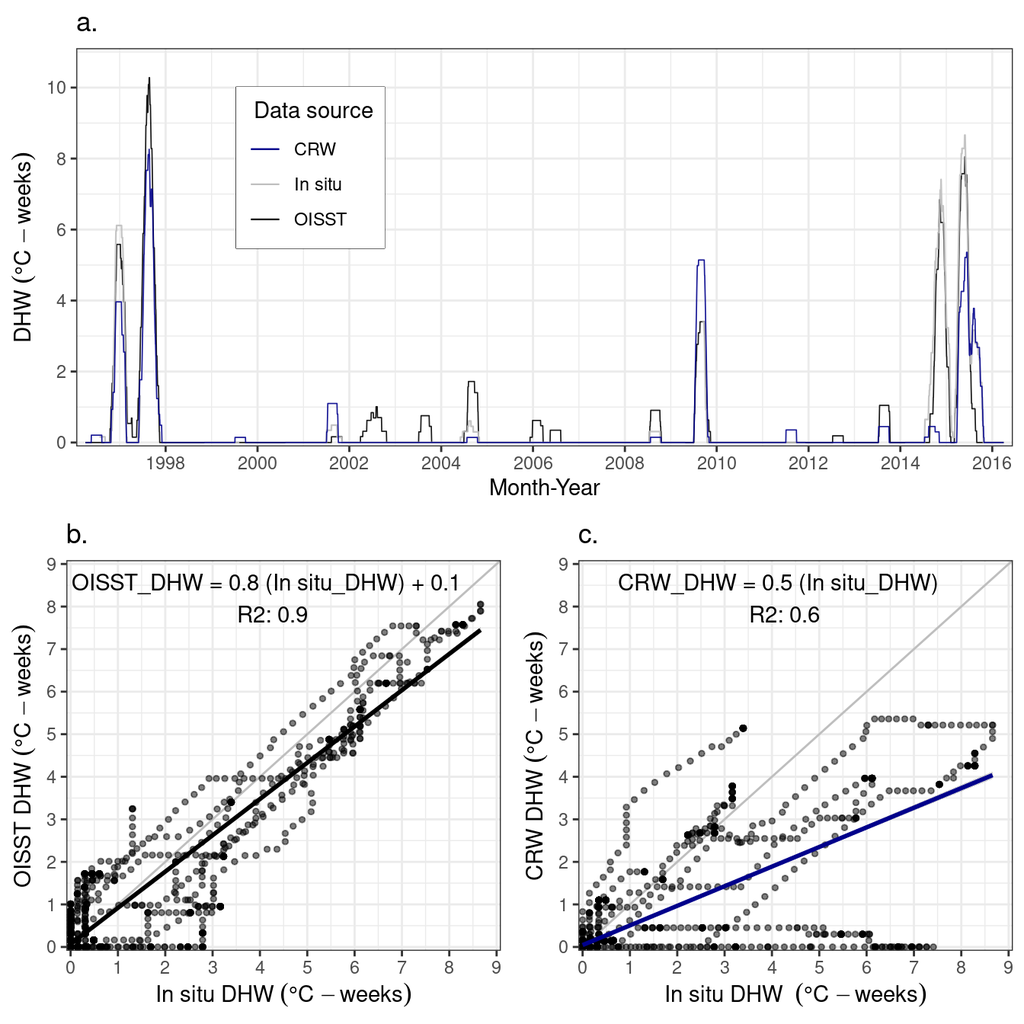

```r
    GCITYvsCRW_DHW2<-ggplot(Wide.data.DHW3, aes(x=DHW.In_situ, y=DHW.CRW_SST)) +
      ggthe_bw + ggtitle("c.")+

      geom_abline(slope = 1, intercept = 0, colour="grey")+
      geom_point(alpha=0.5, size=1)+
      geom_smooth(method = lm, colour="blue4")+

      scale_y_continuous(limits = c(0,9), expand = c(0.01, 0),
                         name=(expression("CRW DHW"~(degree*C~-weeks))),
                         breaks = seq(0,10, by=1))+
      scale_x_continuous(limits = c(0,9), expand = c(0.01, 0),
                         name=(expression("In situ DHW "~(degree*C~-weeks))),
                         breaks = seq(0,10, by=1))+
      annotate("text", x = 4.2, y = 8.2, label = "CRW_DHW = 0.5 (In situ_DHW) \n R2: 0.6")
    #GCITYvsCRW_DHW2
    #ggsave(file="Outputs/DHW_IS_CRW_2.svg", plot=GCITYvsCRW_DHW2, width=4, height=3.5)


# d. OI differences

    Wide.data.DHW3$OI_Difference<-
      (Wide.data.DHW3$DHW.OI_SST-Wide.data.DHW3$DHW.In_situ)

    OI_DHW_Residuals2<-ggplot(Wide.data.DHW3, aes(x=DHW.In_situ, y=OI_Difference)) +
      ggthe_bw+ ggtitle("d.") +

      geom_abline(slope = 0, intercept = 0, colour="grey") +
      geom_point(alpha=0.5, size=1)+
      geom_smooth(method = lm, colour="black")+

      scale_y_continuous(limits = c(-3,3), expand = c(0, 0),
                         name=(expression("OI difference"~(degree*C~-weeks))),
                         breaks = seq(-3,3, by=0.5))+
      scale_x_continuous(limits = c(0,9), expand = c(0.01, 0),
                         name=(expression("In situ DHW"~(degree*C~-weeks))),
                         breaks = seq(0,10, by=1))
    #OI_DHW_Residuals2
    #ggsave(file="Outputs/DHW_OI_Differences.svg", plot=OI_DHW_Residuals2, width=4, height=3.5)


# e. OI differences

    Wide.data.DHW3$CRW_Difference<-
      (Wide.data.DHW3$DHW.CRW_SST-Wide.data.DHW3$DHW.In_situ)

    CRW_DHW_Residuals2<-ggplot(Wide.data.DHW3, aes(x=DHW.In_situ, y=CRW_Difference)) +
      ggthe_bw + ggtitle("e.") +

      geom_abline(slope = 0, intercept = 0, colour="grey")+
      geom_point(alpha=0.5, size=1)+
      geom_smooth(method = lm, colour="blue4")+

      scale_y_continuous(limits = c(-3,3), expand = c(0, 0),
                         name=(expression("CRW difference"~(degree*C))),
                         breaks = seq(-3,3, by=0.5))+
      scale_x_continuous(limits = c(0,9), expand = c(0.01, 0),
                         name=(expression("In situ"~(degree*C))),
                         breaks = seq(0,10, by=1))
    #CRW_DHW_Residuals2
    #ggsave(file="Outputs/DHW_CRW_Differences.svg", plot=CRW_DHW_Residuals2, width=4, height=3.5)


Sources4<-grid.arrange(
  DHWSource2, arrangeGrob(GCITYvsOI_DHW2,GCITYvsCRW_DHW2, ncol=2), heights=c(5/10, 5/10), ncol = 1)
```

```r
#ggsave(file="Outputs/DHW_Sourcess2.svg", plot=Sources4, width=7, height=8)
```

# 6. Other ENSO characteristics (Supplementary Information)

## 6.1 HotSpots magnitude

Other way to compare ENSOs is to look at the magnitude and number of the Hot Spots

### Figure S3?

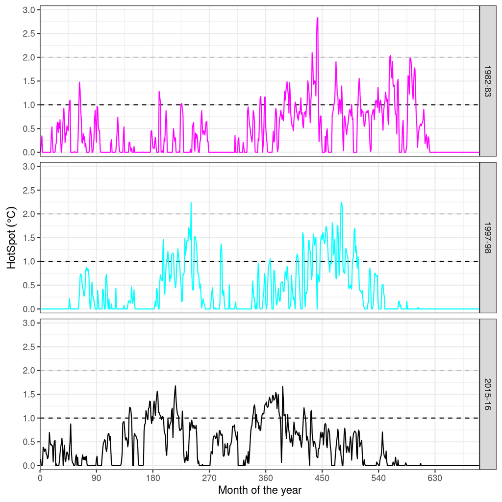

```r
# Supplemantary Figure ?

  SupplumentFigure3a<-ggplot(Nino.OI_data, aes(x=Days)) + ggthe_bw +
      theme(legend.box.background = element_rect(),
            legend.position = "none") +

      geom_hline(yintercept=1, linetype="dashed", color="black")+
      geom_hline(yintercept=2, linetype="dashed", color="grey")+
      scale_x_continuous(limits = c(0,701), expand = c(0, 0),
                         name=("Month of the year"),
                         breaks = seq(0,701, by= 90))+
      scale_y_continuous(limits = c(0,3),
                       name=(expression("HotSpot"~(degree*C))), expand = c(0.02, 0.03),
                         breaks = seq(0,3, by=0.5))

  SupplumentFigure3a <-SupplumentFigure3a +
      #geom_point(aes(y = HotSpot, colour = factor(Event)), size=0.02) +
      geom_line(aes(y = HotSpot, colour = factor(Event))) +

      scale_colour_manual(values = c("magenta","cyan", "black"), name="ENSO")+
      #geom_point(aes(y = Clima_Norm, size=1)) +
      facet_grid(Event~.)
  SupplumentFigure3a
```

```r
  #ggsave(file="C.Outputs/Figure_S3.svg", plot=SupplumentFigure3a, width=6, height=5)
```

##6.2 Number of HS higher than 0, 1, 2, and 3C, area under HS curve

```r
    # Number of HotSpots; HS > 1
        HS_N_1<-as.data.frame(Nino.OI_data %>%
              group_by(Event) %>%
              summarize(N = n(),
                        Cont=sum (HotSpot>=1)))
        HS_N_1
```

| Event | N | Cont |
| --- | --- | --- |
| 1982-83 | 730 | 95 |
| 1997-98 | 730 | 89 |
| 2015-16 | 731 | 89 |

```r
    # Number of HotSpots; 0<HS<1
        HS_N_0_1<-as.data.frame(Nino.OI_data %>%
              group_by(Event) %>%
              summarize(N = n(),
                        Cont=sum (HotSpot>0 & HotSpot<1)))
        HS_N_0_1
```

| Event | N | Cont |
| --- | --- | --- |
| 1982-83 | 730 | 300 |
| 1997-98 | 730 | 253 |
| 2015-16 | 731 | 357 |

```r
    # Number of HotSpots; 1<HS<2
        HS_N_1_2<-as.data.frame(Nino.OI_data %>%
              group_by(Event) %>%
              summarize(N = n(),
                        Cont=sum (HotSpot>=1 & HotSpot<2)))
        HS_N_1_2
```

| Event | N | Cont |
| --- | --- | --- |
| 1982-83 | 730 | 89 |
| 1997-98 | 730 | 85 |
| 2015-16 | 731 | 89 |

```r
    # Number of HotSpots; 2<HS<3
        HS_N_2_3<-as.data.frame(Nino.OI_data %>%
              group_by(Event) %>%
              summarize(N = n(),
                        Cont=sum (HotSpot>=2 & HotSpot<3)))
        HS_N_2_3
```

| Event | N | Cont |
| --- | --- | --- |
| 1982-83 | 730 | 6 |
| 1997-98 | 730 | 4 |
| 2015-16 | 731 | 0 |

```r
# Area under of (HS>0)
  HS_Aggregated<-as.data.frame(Nino.OI_data %>%
        group_by(Event) %>%
        summarize(Sum = sum (HotSpot)))
  HS_Aggregated
```

| Event | Sum |
| --- | --- |
| 1982-83 | 280.8813 |
| 1997-98 | 234.8573 |
| 2015-16 | 273.5942 |

```r
# Area under of (HS>1)
  HS1_Aggregated<-as.data.frame(Nino.OI_data %>%
        group_by(Event) %>%
        summarize(Sum = sum (HotSpot[HotSpot>1])))
  HS1_Aggregated
```

| Event | Sum |
| --- | --- |
| 1982-83 | 131.2770 |
| 1997-98 | 123.5437 |
| 2015-16 | 108.7137 |

```r
# Area under (HS>2)
  HS2_Aggregated<-as.data.frame(Nino.OI_data %>%
        group_by(Event) %>%
        summarize(Sum = sum (HotSpot[HotSpot>2])))
  HS2_Aggregated
```

| Event | Sum |
| --- | --- |
| 1982-83 | 14.223285 |
| 1997-98 | 8.782192 |
| 2015-16 | 0.000000 |